# HR Analytics Data Cleaning

## Check Missing Values

Use `df.isnull().sum()` to identify missing values present in each column of the dataset.

```python
df.isnull().sum()
```

```
Age                         0
Attrition                   0
BusinessTravel              0
DailyRate                   0
Department                  0
DistanceFromHome            0
Education                   0
EducationField              0
EmployeeCount               0
EmployeeNumber              0
EnvironmentSatisfaction     0
Gender                      0
HourlyRate                  0
JobInvolvement              0
JobLevel                    0
JobRole                     0
JobSatisfaction             0
MaritalStatus               0
MonthlyIncome               0
MonthlyRate                 0
NumCompaniesWorked          0
Over18                      0
OverTime                    0
PercentSalaryHike           0
PerformanceRating           0
RelationshipSatisfaction    0
StandardHours               0
StockOptionLevel            0
TotalWorkingYears           0
TrainingTimesLastYear       0
WorkLifeBalance             0
YearsAtCompany              0
YearsInCurrentRole          0
YearsSinceLastPromotion     0
YearsWithCurrManager        0
dtype: int64
```

## Check Duplicate Records

Use `df.duplicated().sum()` to identify duplicate rows in the dataset before data cleaning.

```python
df.duplicated().sum()
```

```
np.int64(0)
```

## Attrition Distribution

Use `value_counts()` to analyze the distribution of employees who stayed and employees who left the company.

```python
df['Attrition'].value_counts()
```

```
Attrition
No     1233
Yes     237
Name: count, dtype: int64
```

## Attrition Visualization

Use a countplot to visualize employee attrition distribution in the organization.

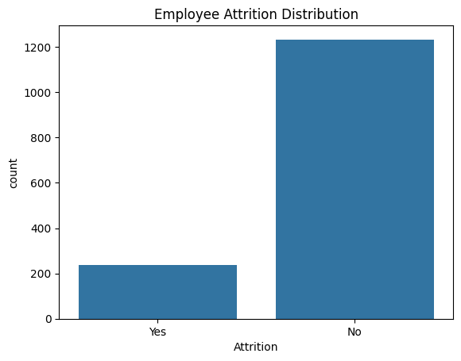

```python
sns.countplot(x='Attrition', data=df)
plt.title('Employee Attrition Distribution')
plt.show()
```

## Department Distribution

Use `value_counts()` to analyze employee distribution across different departments.

```python
df['Department'].value_counts()
```

```
Department
Research & Development    961
Sales                     446
Human Resources            63
Name: count, dtype: int64
```

## Department Visualization

Use a countplot to visualize employee distribution across departments.

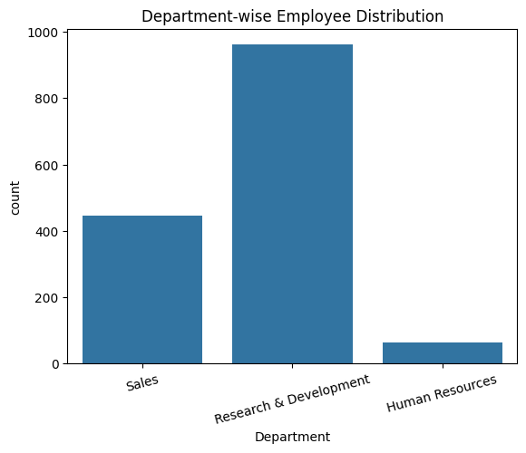

```python
sns.countplot(x='Department', data=df)
plt.title('Department-wise Employee Distribution')
plt.xticks(rotation=15)
plt.show()
```

## Gender Distribution

Use `value_counts()` to analyze the gender distribution of employees in the organization.

```python
df['Gender'].value_counts()
```

```
Gender
Male      882
Female    588
Name: count, dtype: int64
```

## Gender Visualization

Use a countplot to visualize the number of male and female employees.

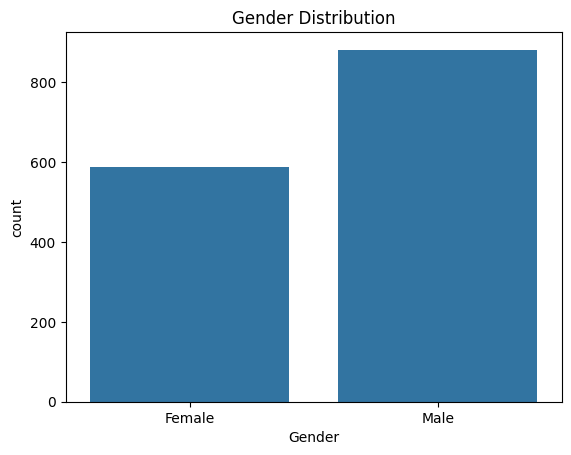

```python
sns.countplot(x='Gender', data=df)
plt.title('Gender Distribution')
plt.show()
```

## Education Field Distribution

Use `value_counts()` to analyze employee distribution across different education fields.

```python
df['EducationField'].value_counts()
```

```
EducationField
Life Sciences       606
Medical             464
Marketing           159
Technical Degree    132
Other                82
Human Resources      27
Name: count, dtype: int64
```

## Education Field Visualization

Use a countplot to visualize employee distribution across education fields.

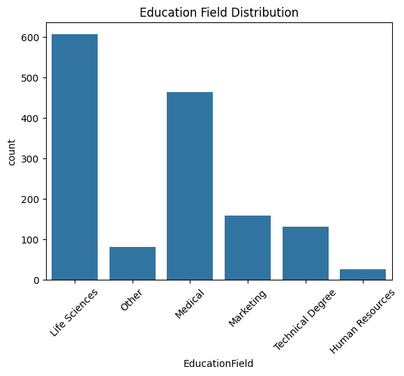

```python
sns.countplot(x='EducationField', data=df)
plt.title('Education Field Distribution')
plt.xticks(rotation=45)
plt.show()
```

## Job Role Distribution

Use `value_counts()` to analyze employee distribution across different job roles.

```python
df['JobRole'].value_counts()
```

```
JobRole
Sales Executive              326
Research Scientist           292
Laboratory Technician        259
Manufacturing Director       145
Healthcare Representative    131
Manager                      102
Sales Representative          83
Research Director             80
Human Resources               52
Name: count, dtype: int64
```

## Job Role Visualization

Use a countplot to visualize employee distribution across different job roles.

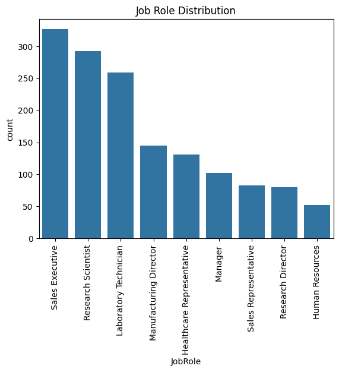

```python
sns.countplot(x='JobRole', data=df)
plt.title('Job Role Distribution')
plt.xticks(rotation=90)
plt.show()
```

## Monthly Income Distribution

Use a histogram to analyze the distribution of employee monthly income.

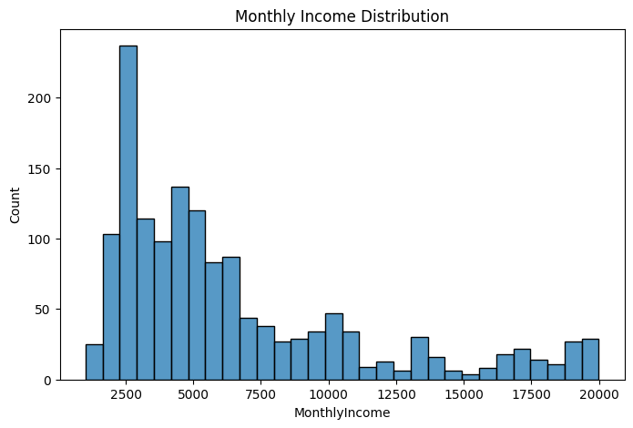

```python
plt.figure(figsize=(8,5))
sns.histplot(df['MonthlyIncome'], bins=30)
plt.title('Monthly Income Distribution')
plt.show()
```

## Age Distribution

Use a histogram to analyze the age distribution of employees in the organization.

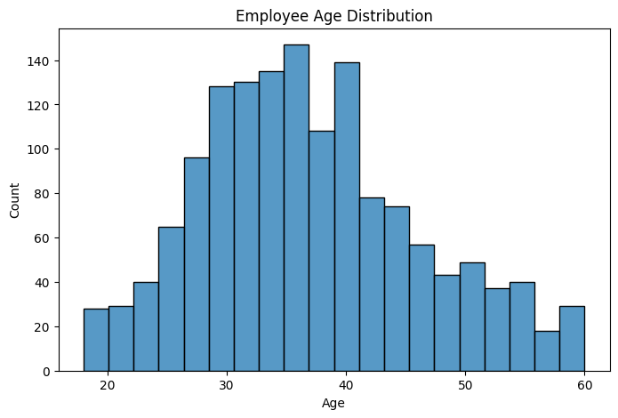

```python
plt.figure(figsize=(8,5))
sns.histplot(df['Age'], bins=20)
plt.title('Employee Age Distribution')
plt.show()
```

## Attrition by Department

Use a countplot to analyze employee attrition across different departments.

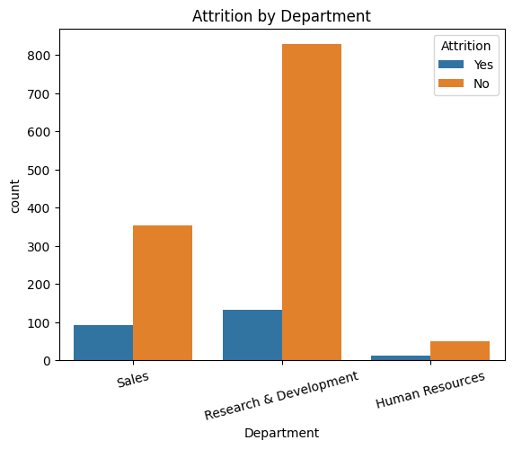

```python
sns.countplot(x='Department', hue='Attrition', data=df)
plt.title('Attrition by Department')
plt.xticks(rotation=15)
plt.show()
```

## Attrition by Gender

Use a countplot to compare attrition distribution between male and female employees.

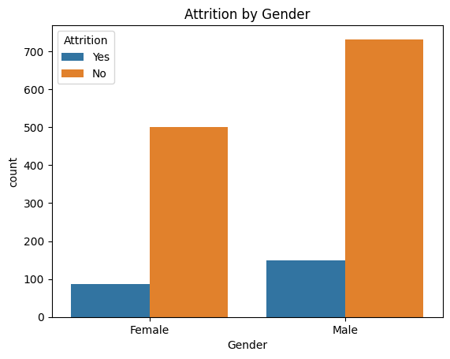

```python
sns.countplot(x='Gender', hue='Attrition', data=df)
plt.title('Attrition by Gender')
plt.show()
```

## Monthly Income by Attrition

Use a boxplot to compare monthly income distribution between employees who stayed and employees who left.

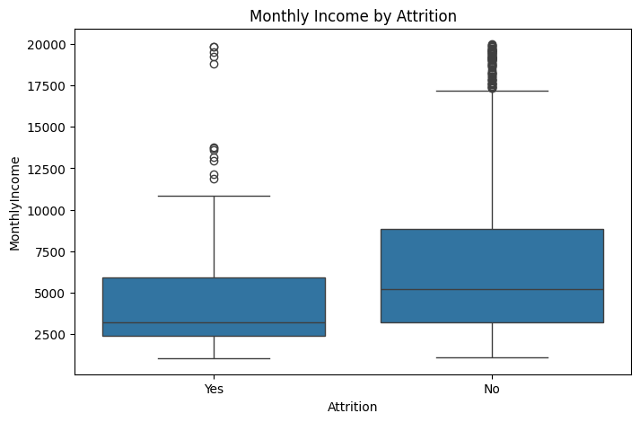

```python
plt.figure(figsize=(8,5))
sns.boxplot(x='Attrition', y='MonthlyIncome', data=df)
plt.title('Monthly Income by Attrition')
plt.show()
```

## Age by Attrition

Use a boxplot to analyze age distribution based on employee attrition.

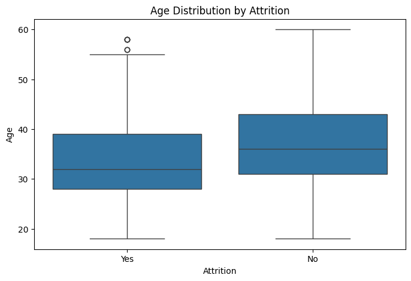

```python
plt.figure(figsize=(8,5))
sns.boxplot(x='Attrition', y='Age', data=df)
plt.title('Age Distribution by Attrition')
plt.show()
```

## Correlation Analysis

Use a correlation matrix to identify relationships between numerical variables in the dataset.

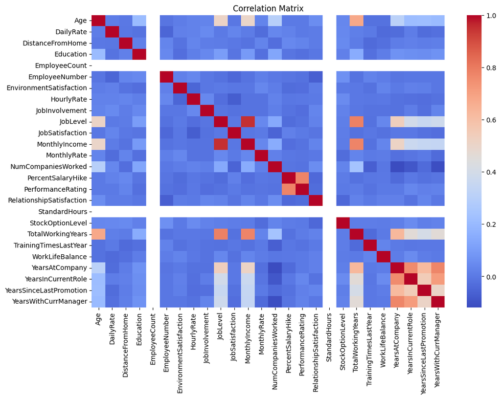

```python
plt.figure(figsize=(12,8))
sns.heatmap(df.corr(numeric_only=True), cmap='coolwarm')
plt.title('Correlation Matrix')
plt.show()
```

## Average Monthly Income by Department

Use `groupby()` to analyze the average monthly income across different departments.

```python
df.groupby('Department')['MonthlyIncome'].mean()
```

```
Department
Human Resources           6654.507937
Research & Development    6281.252862
Sales                     6959.172646
Name: MonthlyIncome, dtype: float64
```

## Average Monthly Income Visualization

Use a barplot to visualize average monthly income across departments.

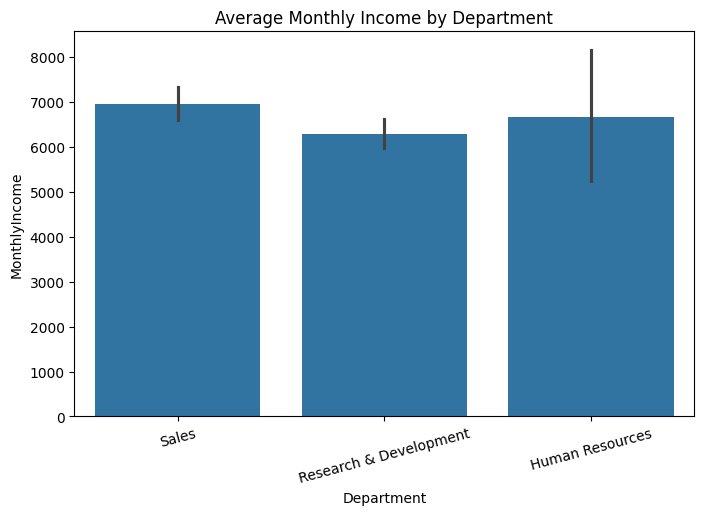

```python
plt.figure(figsize=(8,5))
sns.barplot(x='Department', y='MonthlyIncome', data=df)
plt.title('Average Monthly Income by Department')
plt.xticks(rotation=15)
plt.show()
```

## Average Age by Job Role

Use `groupby()` to analyze the average employee age across different job roles.

```python
df.groupby('JobRole')['Age'].mean().sort_values(ascending=False)
```

```
JobRole
Manager                      46.764706
Research Director            44.000000
Healthcare Representative    39.809160
Manufacturing Director       38.296552
Sales Executive              36.889571
Human Resources              35.500000
Research Scientist           34.236301
Laboratory Technician        34.096525
Sales Representative         30.361446
Name: Age, dtype: float64
```

## Attrition Percentage

Calculate the percentage of employees who left the organization.

```python
attrition_rate = (df['Attrition'].value_counts(normalize=True) * 100)
attrition_rate
```

```
Attrition
No     83.877551
Yes    16.122449
Name: proportion, dtype: float64
```

## Conclusion

The initial exploratory data analysis identified key employee trends related to attrition, salary distribution, department performance, age patterns, and workforce demographics. These insights will support further business analysis and predictive modeling in upcoming notebooks.